# Challenge

In the next **two notebook assignments**, our overall goal will be to produce a *physics-based* model of the truck coast-down experiment you saw in Reading 06.

In Reading 6, you created an *empirical model* for the velocity of the blue toy truck coasting to a stop. In Reading 5, you did the same for a tank of water emptying through a valve. Data from these two experiments (which was given to you in each relevant reading) are shown in the cell below:

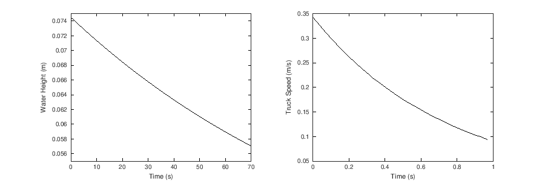

```matlab
tankdata = load('reading5data.txt');
truckdata = load('reading6data.txt');
figure(1, 'position',[0,0,900,300]);
subplot(1,2,1)
plot(tankdata(:,1),tankdata(:,2),'k')
xlabel('Time (s)')
ylabel('Water Height (m)')
subplot(1,2,2)
plot(truckdata(:,1),truckdata(:,2),'k')
xlabel('Time (s)')
ylabel('Truck Speed (m/s)')
```

Curiously, while the y-scale and time scale on each plot is wildly different, the *shapes* of the two plots are the same. This course, which is designed to teach you the *systems approach* to engineering modeling, should help you understand these two problems by seeing the *physical similarity* between them. This takes time, and it requires that we have a *physical understanding* of what is happening in each problem.

For the truck problem, we do have some tools we can use to understand the physics, so **understanding the physics behind the truck's coasting behavior is a good first step towards understanding the physics behind both problems.**

The empirical model from Reading 6 is great, but it does little to illuminate the physics. Further, an empirical model doesn't tell us how (or whether) the truck would slow down differently if we added weight to its bed, or changed the size of its wheels. Physical or physics-based models are superior to purely empirical ones because they allow us to **predict the effects of design changes** on the behavior of our system.

Put simply, a physics-based model is better because it *generalizes* to different model configurations better than an empirical one does.

While Newton's laws are a good starting place for developing a physics-based model of the truck, there are phenomena governing the truck's motion that we have not seen before. Your challenge today is to build the tools you will need to understand the physical phenomena that make the truck's behavior resemble the tank height behavior. We will look at the truck example together, and then you will be asked to develop a model of a new, similar system in today's assignment.

## Challenge: Scoping

We will begin as we always do: by "scoping" a model for the truck system, showing the system's physical boundary along with notation indicating what crosses into and out of the system boundary, along with any relevant quantities that are stored. Here, we note that the truck is moving so it stores kinetic energy, and this energy leaves the system as the truck slows down in the form of losses due to friction.

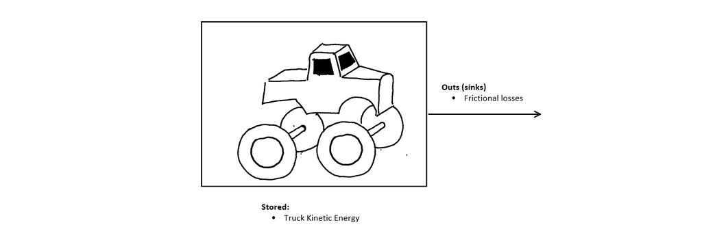

## Challenge: Model Construction

Treating the model of the truck this way, we might create an FBD of the truck, realizing that the only external force acting on it that causes any change in momentum is friction. Normal force and gravity balance one another out, and there is no change of momentum (no acceleration) in the y-direction.

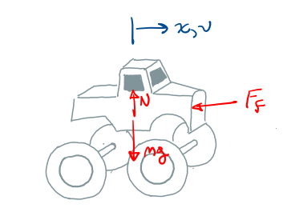

Then, we might write Newton's second law as:

$$\sum \vec{F} = m\vec{\dot{v}} = N\hat{j} - mg\hat{j} - F_f \hat{i}$$

Recognizing that the normal force and gravity will cancel one another, and that $\vec{v}=v\hat{i}$, we can write the x-component of Newton's second law to obtain:

$$m\dot{v} = -F_f$$

Our only model for friction so far is $F_f = \mu N = \mu mg$, and if we made that substitution and solved for the truck's acceleration, $\dot{v}$, we would get:

$$\dot{v} = -\mu g $$

This equation says that acceleration is a constant! This equation, unfortunately, **will *not* describe the behavior of the truck that we measured**, because we have *observed* that the acceleration of the truck is not a constant, and that its magnitude decreases with decreasing truck speed. However, we know there *must* be some sort of frictional force acting on the truck, or else it would keep rolling forever at a constant velocity, via Newton's 1st law.

To understand what is going on here, it is necessary to ask ourselves: "where is the friction coming from?"

The answer, as you might have guessed, is that the frictional force is a result of the interaction between the truck's axle and the truck's body. In order for the axle to turn, the body of the truck has a *bearing* installed for each. Bearings come in many shapes and sizes, but nearly all are *lubricated* interfaces between two parts that either slide or rotate relative to one another. Two types of bearing are shown below: the plain bearing and the ball bearing.

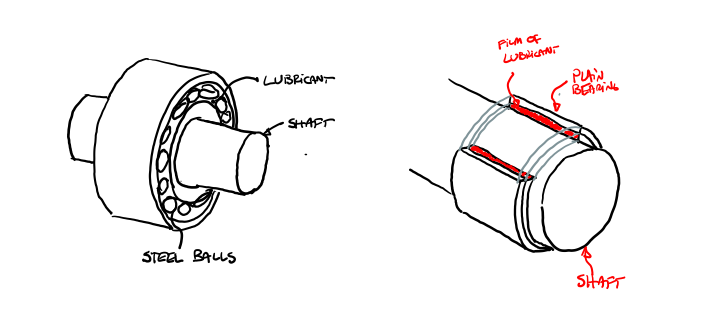

In our first pass at the model, it seemed that the friction slowing the truck must have come from the ground. There is, indeed, friction between the wheels and the ground, but it is difficult to know what it is, since the wheels are not sliding. They are *rolling without slip*, and the frictional force applied to the wheels by the ground is just enough at any moment to keep the wheels from sliding. Friction, as it turns out, is only well-modeled by a constant when two **dry** objects are **sliding** significantly relative to one another.

In order to understand the truck's bearings and how they produce friction, we need to update our tool set for model construction using Newton's laws to include **rotating** systems. This is the topic of the next few sections.

# Disciplined Process Model Construction Using Newton's Laws on *Rotating* Systems

## Torque or Moment

A torque (also called a 'moment') is applied to an object any time a force is applied at some distance from a reference point. **An object to which an imbalanced torque is applied will tend to *rotate*.**

If the distance from the reference point to the application point of the force is defined by a position vector $\vec{r}$, as shown below:

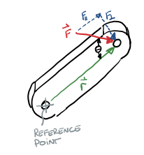

Then the magnitude of the torque applied with respect to the reference point is the product of the position vector's magnitude and the component of the force vector that is *perpendicular* to the position vector:

$$T = r\cdot F_\perp$$

Think about the picture above and imagine that you squeezed the object shown with your thumb and forefinger at the reference point. If the force $\vec{F}$ was pointed directly perpendicular to the position vector $\vec{r}$, it would be hard to keep the object from rotating... and harder yet if the position vector got larger! But if the force vector was pointed either directly towards or directly away from your grip, the object would not "want" to rotate at all! This is the intuitive definition of the mathematical equation above, relating $F_\perp$ and $r$.

The definition of the component $F_\perp$ depends on the specific geometry of a particular problem, but if the angle $\theta$ is defined as in the figure above, then we can compute that $F_\perp=F\sin\theta$, where $F$ is the magnitude of the force vector $\vec{F}$.

The *direction* of the torque is said to be perpendicular to the plane defined by the position and force vectors. Specifically, its direction can be surmised using the "right hand rule," in which one curls the fingers of the right hand from the position vector into the direction of the applied force. The direction of the torque is shown by the direction in which the thumb points. Note that this means that the applied *torque* will always point into or out of the page when considering planar motion.

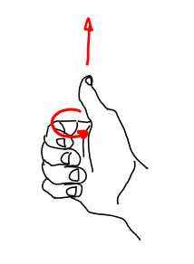

If you've never heard of the right-hand rule, or you need a refresher, check out this video!

[video not shown]

This rule for computing the magnitude and direction of a *torque vector* $\vec{T}$ is a description of what is called the *[vector cross product](https://en.wikipedia.org/wiki/Cross_product).* In terms of the vector cross product, torque is written:

$$\vec{T} = \vec{r}\times \vec{F}$$

Many times, the method of computing the direction and magnitude of torque explained above, as the "distance times the perpendicular component of force," is the easiest way. However, in cases where oblique forces are applied at odd distances from a reference point, more formal methods for computing the cross product can be more useful. In ES103, we will stick with the simpler definition.

## "Couples" or "Pure Torques (moments)"

We said that a force at some perpendicular distance from a reference point is said to produce a *torque* about that reference point. However, an object with a single resultant force applied to it at some offset from its center of gravity will tend to both *translate and rotate*. It is possible to have a situation in which a *Pure Torque,* also called a couple), is applied. A couple occurs when an object is subjected to two or more forces that *sum to zero* via Newton's second law, but together produce a net torque. An example is shown below, in which a cylindrical body is subjected to two forces tangent to the cylinder (and thus perpendicular to the radius $r$).

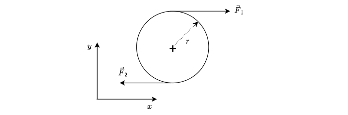

If the two forces $\vec{F}_1$ and $\vec{F}_2$ have a common magnitude $F$, we could see that their vector sum would be $0$, meaning that the cylinder will not have any translational acceleration. However, these two forces each produce a **TORQUE** of $F\cdot r$ that, according to the right-hand rule, will be facing *into the page* and are *clockwise* torques, meaning that the net torque applied to the cylinder will be $T = 2\cdot Fr$.

In situations like these, we will often just represent the cylinder as being exposed to a known *Pure Torque,* which is often shown using an arc-like symbol like the one in the figure below that indicates its direction. In planar problems, counter-clockwise torques are positive, and clockwise torques are negative. This is also due to the right-hand rule, which can be used to show us the directions of positive $x,y,z$ axes as shown below.

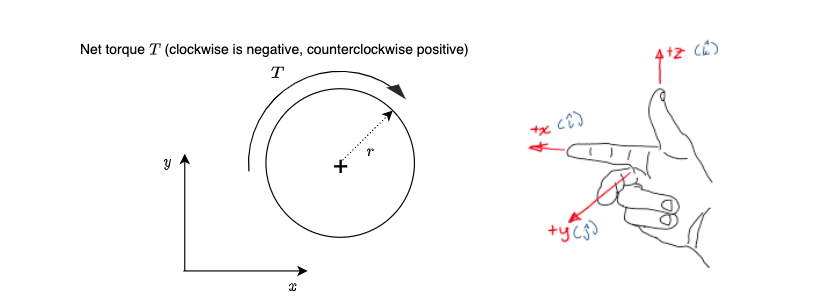

## Newton's Second Law applied to angular momentum for a rigid body rotating about its center of mass in a plane

Newton's second law, a statement about the conservation of momentum, applies to *angular* as well as linear momentum. For a rigid body moving in a plane, angular momentum is defined as:

$$\vec{H} = J \omega \hat{k}$$

Where $\omega$ is the magnitude of the rigid body's *angular velocity* (radians/second), and $J$ is the *mass moment of inertia* of the rigid body. Think of the mass moment of inertia like a "mass for rotation." The larger this number is, the harder it is to accelerate an object in rotation. Notice that the angular velocity $\omega$ points in the $\hat{k}$ direction for an object moving in a plane. This is because of the right-hand rule. When we curl our right-hand fingers in the direction of rotation, our thumb points in the direction of the rotation vector. Some more details about angular velocity can be found [here](https://en.wikipedia.org/wiki/Angular_velocity) if desired.

Mass moment of inertia is a scalar quantity that is related to how mass is distributed in an object. A list of mass moments of inertia is available [here](https://en.wikipedia.org/wiki/List_of_moments_of_inertia), and the formal definition is given as:

$$J = \int r^2dm$$

Where "dm" represents an infinitesimal piece of mass that makes up the rigid body. It is rare that one needs to calculate a mass moment of inertia using this formula-- tables of mass moments of inertia for most common shapes are widely available, and most modern computer-aided design software can compute mass moments of inertia for parts you design. However, looking at the equation is helpful for understanding what moment of inertia *really is*. Imagine an object with all of its mass concentrated at a point. We could calculate that mass's *moment of inertia* with respect to some arbitrary axis as $J = mr^2$. By contrast, a wheel or a cube would have a different moment of inertia, since the mass of those objects is distributed in space.

Angular velocity, which has units of $\frac{rad}{s}$ in the SI system, has a *direction* either into or out of the plane of motion, according to the right-hand rule. With a standard coordinate system defined on a page as $x$ right and $y$ up, counterclockwise rotation is positive (out of the page), and clockwise rotation is negative (into the page). Newton's second law deals with the derivative of momentum. For a rotational system in a non-accelerating (also called "Newtonian") reference frame, we can write:

$$\sum \vec{T} =\frac{d\vec{H}}{dt}$$

where **The angular momentum is computed about a rigid body's center of mass**. If moments (torques) are to be summed about an arbitrary point, this formula *does not, in general, apply*. There are special exceptions to this rule, but we will not treat them here.

As with a translational system, if the rotational inertia of a rigid body is constant, the right-hand side of the above equation can be written as $\frac{d\vec{H}}{dt} = J \dot{\vec{\omega}}$. In making this simplification, *and considering only motion in one plane,* we can write Newton's second law for a rigid body rotating about its center of mass as:

$$\sum \vec{T} = J \vec{\dot{\omega}}$$

You will often see this equation written as a scalar equation for objects that rotate only in one plane (such as a wheel functioning normally. If you imagine a wheel flying off of a car, wobbling and bouncing down the road, you can see that it might have angular velocity about more than one axis of rotation). This scalar version of Newton's second law comes from the fact that if a body rotates only about one axis, its angular velocity (and thus, the torques that produce it) must all be going either into or out of the plane.

In summary, summing the torques about an object's center of mass to see how its *rotational velocity* changes over time is analagous to summing the *forces* applied to an object to see how its *velocity* will change over time.

## Example: Newton's Laws for a rotating plain bearing

You may recall that we needed to develop the concept of torque and angular momentum in order to understand how the *bearings* in the truck's axles contribute to the truck's overall behavior. Let's analyze a "plain bearing" using Newton's laws for rotating systems. We can assume that there is a "known" pure torque $T_2$ acting on the inner race of the bearing, and another "known" pure torque $T_1$ acting on the outer race. The inner and outer races of the bearing move at different velocities, and they are separated by a thin film of lubricant.

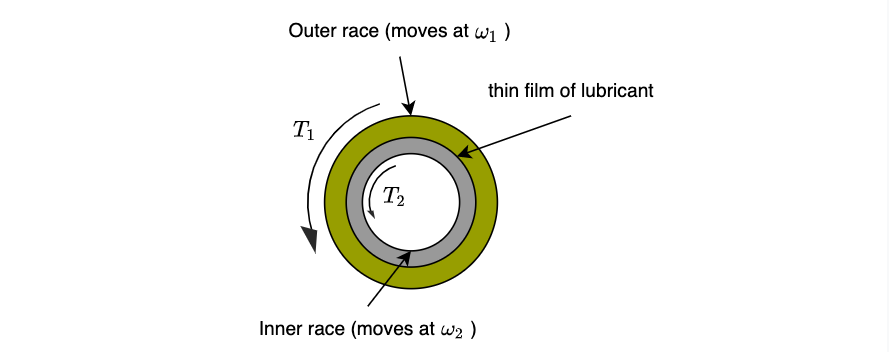

### Scoping

Scoping this system is straightforward. The bearing itself will define our system boundary, and we will assume that the bearing can be modeled by two elements: the inner and outer races. Kinetic enery of the inner and outer races is our stored quantity. The known torques on these inner and outer races originate from outside the system boundary, and have the potential to accelerate the bearing's inner or outer races, increasing stored kinetic energy (especially since both are drawn positive). So they are "sources." The friction in the lubrication between the two races always tends to slow the races down, decreasing the system's total kinetic energy, so it is a "sink."

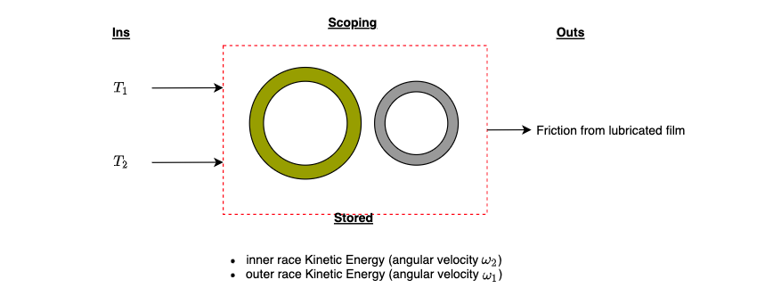

### Model Construction

- Our independent variables will be:
  - the known torques $T_2$ and $T_1$ applied to the inner and outer races, respectively.
  - the moments of inertia $J_1$ and $J_2$ of the outer and inner races, respectively
  - properties of the friction between the inner and outer races (as yet unknown)
- Our dependent variables will be:
  - $\omega_1$, the angular velocity of the outer race (and its derivatives, if needed)
  - $\omega_2$, the angular velocity of the inner race (and its derivatives, if needed)
- To relate the independent and dependent variables, we will use Newton's Laws.

This frictional force, like dry Coulomb friction, **always opposes the relative motion of a body with respect to the surface that is providing the friction**, so this equation assumes that the torque will be positive if $\omega_1>\omega_2$. Depending on how you define your torques, you may need to flip the signs. The "damping constant" $b$ is a property of the bearing's lubricated interface that must be added to our independent variable list.

Our process for relating our independent and dependent variables is to write the Free-Body-Diagram (FBD) for each component, and apply Newton's laws. To do this, we will assume that the outer race is moving faster than the inner race. This will allow us to assume a direction for the frictional torque $T_f$ on each body. If we are wrong, the signs should reverse themselves as long as we're consistent.

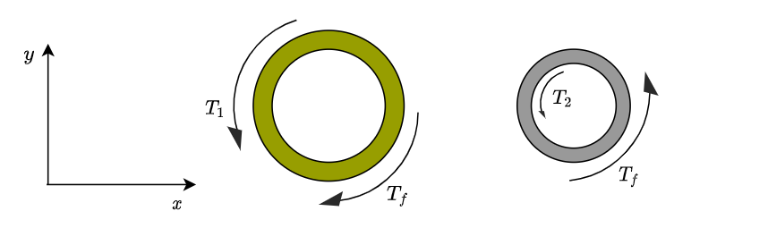

Notice that the frictional torque $T_f$ was drawn in opposite directions on each component. This is because of Newton's third law; if the frictional torque on the outer race is due to the inner race, then Newton's third law states that the inner race must be subjected to an equal and opposite torque by the outer race!!

Applying Newton's Second Law (N2L) for rotation about the outer race's center of mass, assuming the bearing's motion is in plane and therefore all torques and angular velocities are in the $\hat{k}$-direction (out of + or into - the page), we get:

$$\sum T_{outer} = J_{1} \dot{\omega_1} = T_1-T_f$$

Substituting in our linear friction model, we can solve for the outer race's angular acceleration.

$$\dot{\omega_1} = \frac{1}{J_{1}} \left( T_1 - b( \omega_1 - \omega_2)\right)$$

Note that this model now only contains independent and dependent variables, and so it is complete. Examining the units of each term, we find that all are angular accelerations (units of $\frac{rad}{s^2}$). We can also confirm that if $\omega_1>\omega_2$, the friction will be negative as drawn, and the outer race will tend to slow down.

Repeating this process for the inner race yields:

$$\sum T_{2} = J_{2} \dot{\omega_2} = T_2+T_f$$

Substituting in our linear friction model, we can solve for the inner race's angular acceleration.

$$\dot{\omega_2} = \frac{1}{J_{2}} \left(T_2 + b(\omega_1 - \omega_2)\right)$$

Again, all terms have the correct units, and we can see that if $\omega_1>\omega_2$, the outer race is tending to *accelerate* the inner race. If $\omega_2>\omega_1$, the inner race will tend to slow down as expected.

We also see that what we have developed is a model that is actually **TWO** differential equations that are *coupled* to one another; the motion of the inner race depends on the motion of the outer race, and vice versa. At this point in the course, **we do not know how to solve a system of two coupled differential equations**. Therefore, we cannot perform model evaluation for this example.

## Further Simplification of the model

However, it is almost always true that bearings are connected to objects much larger than themselves. On the toy truck, the outer race of each axle's bearing is connected to an object that does not rotate (the chassis)! The inner race is connected to the truck's axle. This simplifies the problem a lot because for the truck, it means that $\omega_1=\dot{\omega}_1 = 0$.

In fact, it is common to further simplify the analysis of bearings when modeling their role in larger systems, because we can often assume that the inner and outer races have *negligible* moments of inertia $J_1$ and $J_2$.

Making this assumption for our system means that, for the outer race, N2L becomes: $$\require{cancel}$$ $$\sum{T_{outer}} = \cancel{J_1}\dot{\omega}_1 = T_1 - T_f$$ And this implies that: $$T_1 = T_f = b(\omega_1-\omega_2)$$ For the inner race, this means that N2L becomes: $$\sum{T_{inner}} = \cancel{J_2}\dot{\omega}_2 = T_2 + T_f$$ And this implies that: $$T_2 = -T_f = -b(\omega_1 -\omega_2)$$

**Taken together, this means that we could really treat the bearing as a *single* "element" in a larger system**, with the following free-body diagram that shows that the external pure torque applied to the bearing must be equal in magnitude and opposite in sign between the inner and outer races, and that this torque will always have a magnitude of $T_b = b(\omega_1-\omega_2)$:

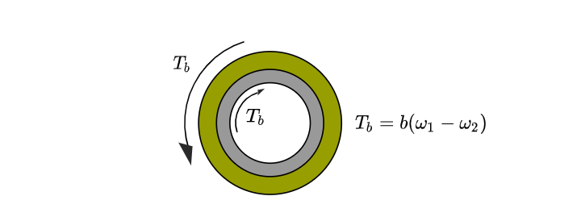

When we make these assumptions, the bearing falls into a special category of element called an "idealized rotational damper," which we formally define below.

## Idealized Rotational and Translational Dampers: Force and Torque

Idealized rotational and translational dampers are fictitious *single elements* in a dynamic system that have insignificant translational and rotational inertia, but that produce a force or torque that resists motion proportionally to the velocity difference between each part of the damper. "True" idealized dampers **do not exist**, because nothing is massless, and almost nothing has a purely linear relationship between force and velocity (or torque and angular velocity). However, *empirical observations* have led scientists and engineers to model many "real" system elements as if they were idealized dampers.

For example, rotational bearings and lubricated sliding contacts are often modeled as idealized dampers, as are translational "shock absorbers" such as those found on a car's suspension. Dampers are often indicated on a drawing using a shorthand sketch of their free body diagrams.

[figure not shown]

Because idealized rotational and translational dampers do not have significant mass, the torque or force (respectively) on each end of the damper must be equal and opposite.

The magnitude of the torque on a rotational damper, as drawn above, is given by:

$$ T_b = b(\omega_1 - \omega_2)$$

Where $b$ is the damper's "damping coefficient." $\omega_1$ represents the angular velocity of one race of the damper, and $\omega_2$ represents the angular velocity of the other race. The damping coefficient $b$ is often experimentally determined, and its units are $\frac{N\cdot m \cdot s}{rad}$ in SI units so that multiplying the coefficient with an angular velocity in $\frac{rad}{s}$ yields a torque in $N\cdot m$. Note that using the right-hand rule, we can confirm that if $\omega_1$ is larger than $\omega_2$, the torque will point "outwards" from each end of the damper.

Similarly, for a translational damper (such as a shock absorber in a car), the equation for the force produced by the damper is given by:

$$ F_b = b(v_1-v_2)$$

The damping coefficient $b$ for a translational damper has units of $\frac{N\cdot s}{m}$ such that multiplying the coefficient by a velocity in $\frac{m}{s}$ produces a force in $N$.

With our new concept of Torque, Angular Momentum, and Idealized Dampers, we can update our disciplined process for model construction using Newton's Laws so that we can apply these concepts to more complex systems.